# REPORT: DHS Vaccination Data

Author: Abraham Adokwei

Jun 11, 2025

# 1 Report Objective

- To assess vaccination data used in the analysis of measles vaccination timing.

# 2 Data Properties

- DHS dataset report from Ghana (GH) published in 2022 under the name GH2022DHS and Individual Recode. This dataset is based on the Phase 8 DHS Survey.
- The children involved in this report are between the ages of 0 and 36 months, reflecting children whose guardians were asked about their child’s vaccination status.
  $$\\$$

Vaccination (censor) status defined:

- A child with a documented date of receiving a measles containing vaccine (MCV) on their vaccination card was considered **uncensored** at the time of the survey. When a guardian recalled that their child had received vaccination but a vaccination card was unavailable or the card date was impossible, the child was considered to be **left censored** at the time of DHS survey; a child reported as unvaccinated at the time of DHS survey was considered to be **right censored** . These were coded as **right censored=0, uncensored=1, left censored=2.**
  $$\\$$

# 3 Description of Data

At the time of the DHS Survey, 5282 children were surveyed. Of this number, 0 had an incomplete or impossible date of birth. This leaves 5282 for analysis.

$$\\$$

# 4 Descriptive Plots

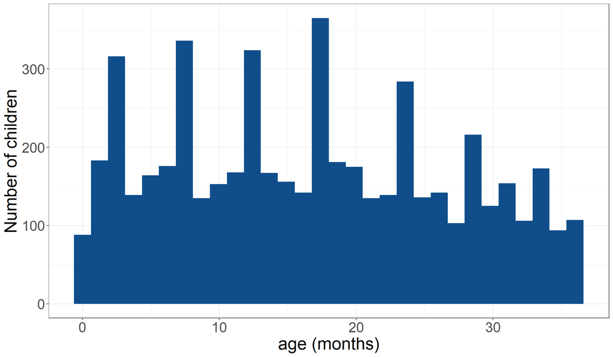

Figure 1: Distribution of children’s age at the time of the survey (N = 5282 )

The mean age of children at the time of the survey was 17 (months) with a standard deviation of 10. About 25% of the children were below 8 (months), 50% were below 16, and 25% were above 25 (months).

$$\\[0.5in]$$

181 children, reflecting 3.43% were missing vaccination status. 4 children, reflecting 0.08% had impossible date of vaccination. In addition, 445 children were excluded from the analysis because they were below the recommended vaccination age set by user (3 months). This leaves a total of 4652 in the data for analysis.
$$\\[0.5in]$$

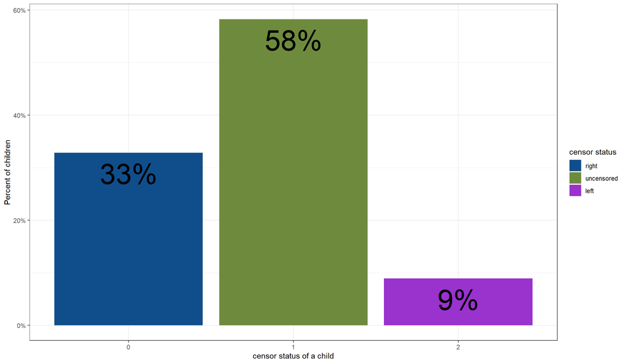

Figure 2: Distribution by censor status (N = 4652 )

Based on our defined censor status above, 1528 (32.8%) of the children had not yet received a MCV at the time of survey; 2710 (58.3%) of them were vaccinated and had documented date of their vaccination; 414 (8.9%) of the children were vaccinated prior to the survey at an unknown date.
$$\\[0.5in]$$

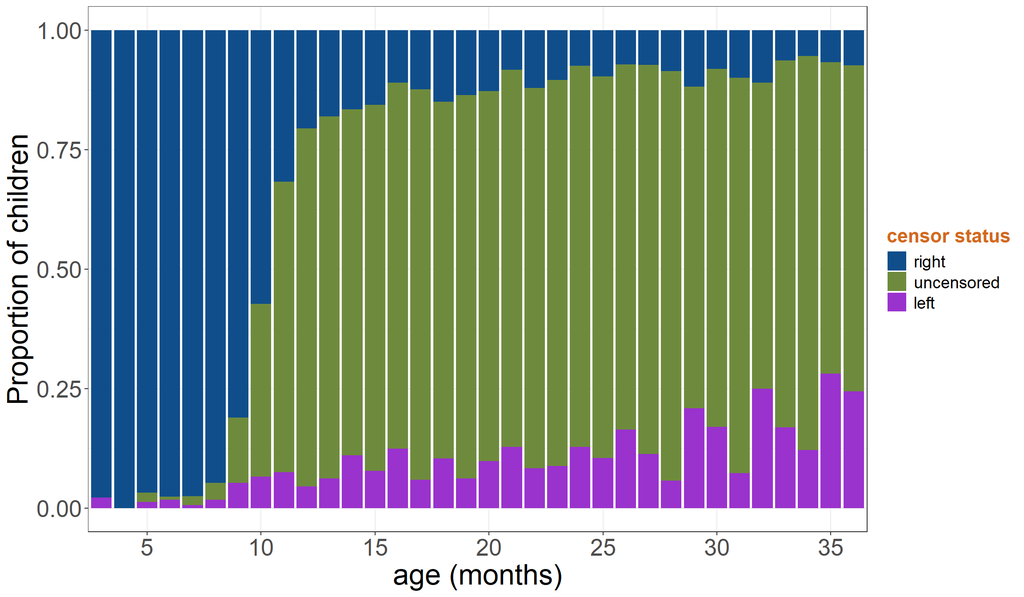

Figure 3: Age-specific distribution of censor status (N= 4652 )

$$\\[0.5in]$$

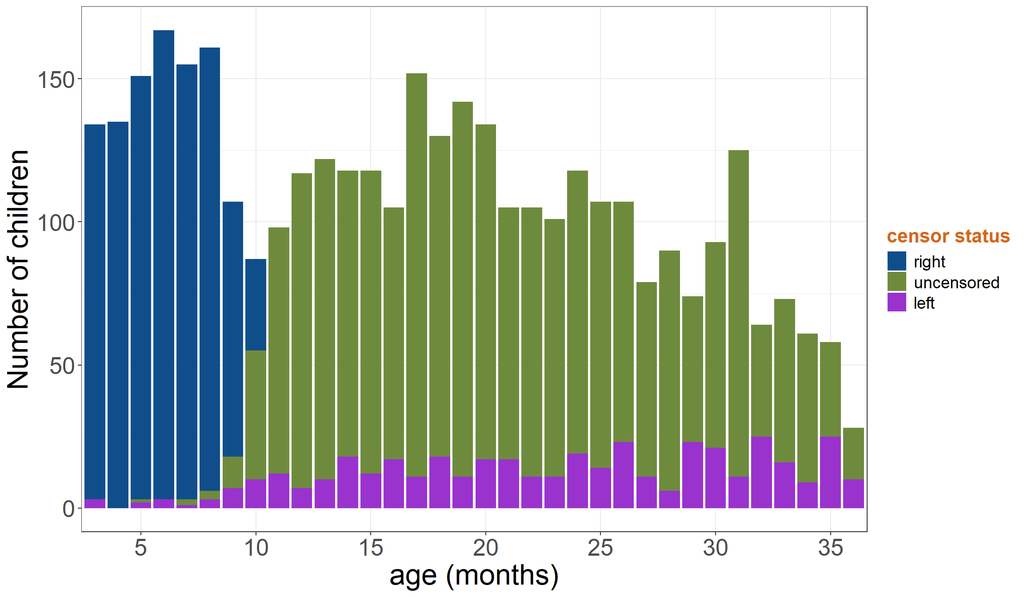

Figure 4: Age-specific distribution of censor status (N= 4652 )

$$\\[0.5in]$$

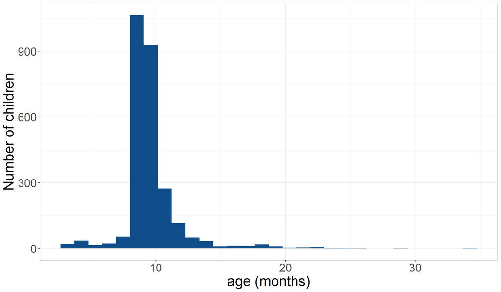

Figure 5: Distribution of children’s vaccination age (uncensored) (N = 2710 )

The mean age of children at the time of vaccination was 10 (months) with a standard deviation of 2. About 25% of the children were below 9 (months), 50% were below 10, and 25% were above 10 (months).

$$\\[0.5in]$$

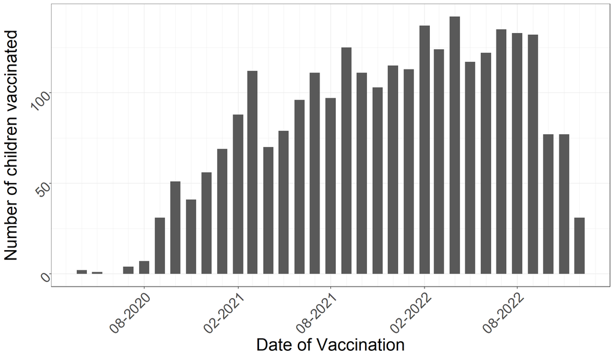

Figure 6: Distribution of vaccination date (N = 2710 )

$\\[5pt]$

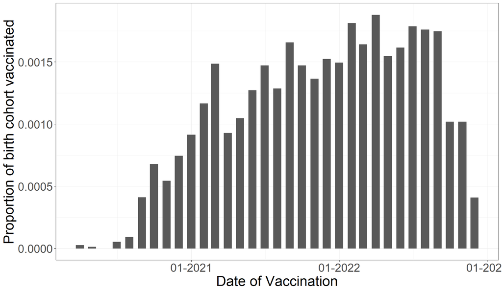

Figure 7: Distribution of vaccination date (N = 2710 )

The period of vaccination for children with proof of vaccination span Apr, 2020 to Dec, 2022 totaling 33 months. On an average, 85 children were vaccinated in a given month with a standard deviation of 43.94. There’s been evidence of increased vaccination efforts due to Supplemental Immunization Activities (SIAs) within certain countries. We attempt to identity such efforts by adopting an outlier detection technique. In *Figure 6*, red colored bars represent vaccination counts beyond 2 standard deviations above the mean ($\ge$ 172.53). Similarly, orange bars represent vaccination counts beyond 3 standard deviations above the mean ($\ge$ 216.46). As indicated above, 0% of the months were above 2 standard deviations and 0% were above 3 standard deviations.

Similar to *Figure 6*, in *Figure 7*, red colored bars represent vaccination proportions beyond 2 standard deviations above the mean ($\ge$ 0.002285). Similarly, orange bars represent vaccination proportions beyond 3 standard deviations above the mean ($\ge$ 0.0028665). We expect that the outliers in *Figure 6* should match those detected in *Figure 7*.

## 4.1 Turnbull Estimates

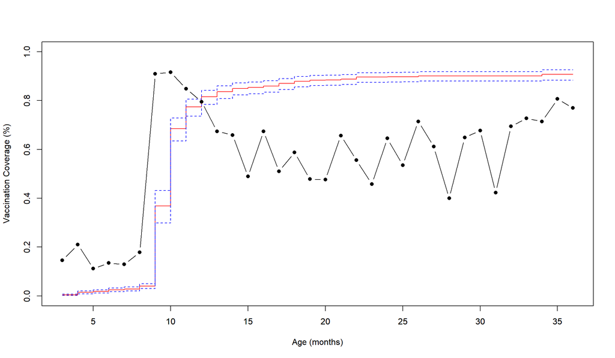